# Common Garden Design

## Intro

Determine randomization strategy and plant placing for 2023 Wrights Lake 2 Planting

```r
library(tidyverse)
library(googlesheets4)
library(ggforce)

is.even <- function(x) x%%2 == 0

popsheet <- "https://docs.google.com/spreadsheets/d/1dUssBAffv-sPPP5D81vx-zQkxf5phQntZb0mVPj7BEs"
```

## get data on germinated seed

**Note: be sure to check the checkbox to grant access on the webpage that opens when you run the code below**

```r
# the original reps
seed <- read_sheet(popsheet,
                   sheet = "germination",
                   na=c("NA", "")
) %>%
  select(parent.pop, mf, rep, `germinated?`)
```

```
✔ Reading from Pops for 2023 WL2.
✔ Range ''germination''.
```

```r
seed
```

| parent.pop | mf | rep | germinated? |
| --- | --- | --- | --- |
| CP2 | 1 | 1 | 1 |
| CP2 | 1 | 2 | 1 |
| CP2 | 1 | 3 | 1 |
| CP2 | 1 | 4 | 1 |
| CP2 | 1 | 5 | 1 |
| CP2 | 1 | 6 | 1 |
| CP2 | 1 | 7 | 1 |
| CP2 | 1 | 8 | 1 |
| CP2 | 1 | 9 | 1 |
| CP2 | 1 | 10 | 1 |

[output cut: 990 more lines]

```r
# extra seed
extra <- read_sheet(popsheet,
                    sheet = "extra mf reps",
                    na=c("NA", "")
) %>%
  filter(`use as experimental` == 1) %>%
  select(-notes) %>%
  rename(`germinated?` = `use as experimental`)
```

```
✔ Reading from Pops for 2023 WL2.
✔ Range ''extra mf reps''.
```

```r
extra
```

| parent.pop | mf | rep | germinated? |
| --- | --- | --- | --- |
| CP2 | 1 | 14 | 1 |
| CP2 | 2 | 14 | 1 |
| CP2 | 3 | 14 | 1 |
| CP2 | 4 | 14 | 1 |
| CP2 | 5 | 14 | 1 |
| CP2 | 7 | 14 | 1 |
| CP2 | 2 | 15 | 1 |
| CP3 | 1 | 14 | 1 |
| CP3 | 3 | 14 | 1 |
| CP3 | 4 | 14 | 1 |

[output cut: 142 more lines]

```r
seed.combined <- bind_rows(seed, extra)

germinated <- seed.combined %>%
  filter(`germinated?`==1)

notgerminated <- seed.combined %>%
  filter(`germinated?` == 0)
```

## assign blocks to germinated

get a histogram of rep count

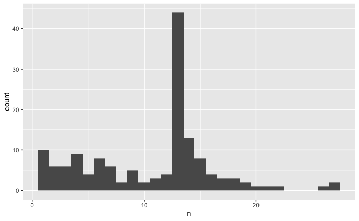

```r
germinated %>%
  group_by(parent.pop, mf) %>%
  summarize(n=n()) %>%
  ggplot(aes(x=n)) +
  geom_histogram(binwidth = 1)
```

```r
germinated %>%
  group_by(parent.pop) %>%
  summarize(n=n()) %>%
  arrange(n)
```

| parent.pop | n |
| --- | --- |
| WV | 3 |
| WR | 15 |
| LV3 | 27 |
| SQ1 | 31 |
| SQ3 | 33 |
| YO4 | 40 |
| FR | 48 |
| WL1 | 48 |
| SQ2 | 61 |
| TM2 | 84 |

[output cut: 13 more lines]

A bit challenging because for pops with few reps total we should be careful to distribute the pops across the blocks.

I think one way this can work is to arrange by pops and mfs and then assign a randomized set of block labels to it.

Full replication is 13 plants per maternal family

```r
#terminology with "germ" prefix is a leftover from UCD2022 when we planted both germinated and ungerminated seed.

germblocks <- LETTERS[1:13]

germreps <- ceiling(nrow(germinated) / length(germblocks) ) # number of times we have to assign blocks

germinated$block <- rep(germblocks, length.out=nrow(germinated))

#for low rep mfs, randomize all mfs in the pop that have have < 13
set.seed(777)
germinated_low_extra_rep <- germinated %>%
  group_by(parent.pop, mf) %>%
  mutate(reps=n()) %>%
  filter(reps < 13 | rep > 13) %>% # because 13 blocks and 13 represents full replication.  Pull mfs with less than 13 reps and pull extra reps from those with > 13
  group_by(parent.pop) %>%
  mutate(block= {map(1:ceiling(n()/13), ~ sample(germblocks)) %>% #sampling without replacement 1 block at a time helps with even distribution across blocks.
      unlist() %>% magrittr::extract(1:n())}, # clean up last rep
  ) %>%
  ungroup()

#For high rep mfs, just use the sequentially assigned blocks
germinated_fullrep <- germinated %>%
  group_by(parent.pop, mf) %>%
  mutate(reps=n()) %>%
  filter(reps >= 13, rep < 14) %>% #get those plants corresponding to full germination but not extra
  ungroup()

germinated <- bind_rows(germinated_low_extra_rep, germinated_fullrep) %>% arrange(parent.pop, mf)

germinated
```

| parent.pop | mf | rep | germinated? | block | reps |
| --- | --- | --- | --- | --- | --- |
| BH | 1 | 1 | 1 | L | 13 |
| BH | 1 | 2 | 1 | M | 13 |
| BH | 1 | 3 | 1 | A | 13 |
| BH | 1 | 4 | 1 | B | 13 |
| BH | 1 | 5 | 1 | C | 13 |
| BH | 1 | 6 | 1 | D | 13 |
| BH | 1 | 7 | 1 | E | 13 |
| BH | 1 | 8 | 1 | F | 13 |
| BH | 1 | 9 | 1 | G | 13 |
| BH | 1 | 10 | 1 | H | 13 |

[output cut: 990 more lines]

reality check distribution across mfs

```r
germinated %>%
  pivot_wider(id_cols = c(parent.pop, mf), names_from = block, values_from = `germinated?`, values_fill = 0, values_fn = sum)
```

| parent.pop | mf | L | M | A | B | C | D | E | F | G | H | I | J | K |
| --- | --- | --- | --- | --- | --- | --- | --- | --- | --- | --- | --- | --- | --- | --- |
| BH | 1 | 1 | 1 | 1 | 1 | 1 | 1 | 1 | 1 | 1 | 1 | 1 | 1 | 1 |
| BH | 2 | 1 | 1 | 1 | 1 | 1 | 1 | 1 | 1 | 1 | 1 | 1 | 1 | 1 |
| BH | 3 | 1 | 1 | 1 | 1 | 1 | 1 | 1 | 1 | 1 | 1 | 1 | 1 | 1 |
| BH | 4 | 1 | 1 | 1 | 1 | 1 | 1 | 1 | 1 | 1 | 1 | 1 | 1 | 1 |
| BH | 5 | 1 | 1 | 1 | 1 | 1 | 1 | 1 | 1 | 1 | 1 | 1 | 1 | 1 |
| BH | 6 | 1 | 1 | 1 | 1 | 1 | 1 | 1 | 1 | 1 | 1 | 1 | 1 | 1 |
| BH | 7 | 1 | 1 | 1 | 1 | 1 | 1 | 1 | 1 | 1 | 1 | 1 | 1 | 1 |
| CC | 1 | 1 | 1 | 1 | 1 | 1 | 1 | 1 | 1 | 1 | 1 | 1 | 1 | 1 |
| CC | 2 | 1 | 1 | 1 | 1 | 1 | 1 | 1 | 1 | 1 | 1 | 1 | 1 | 1 |
| CC | 3 | 1 | 1 | 1 | 1 | 1 | 1 | 1 | 1 | 1 | 1 | 1 | 1 | 1 |

[output cut: 138 more lines]

reality check distribution across parent.pops

```r
germinated %>%
  pivot_wider(id_cols = parent.pop, names_from = block, values_from = `germinated?`, values_fill = 0, values_fn = sum)
```

| parent.pop | L | M | A | B | C | D | E | F | G | H | I | J | K |
| --- | --- | --- | --- | --- | --- | --- | --- | --- | --- | --- | --- | --- | --- |
| BH | 7 | 7 | 7 | 7 | 7 | 7 | 7 | 7 | 7 | 7 | 7 | 7 | 7 |
| CC | 7 | 7 | 7 | 7 | 7 | 7 | 7 | 7 | 7 | 7 | 7 | 7 | 7 |
| CP2 | 7 | 7 | 7 | 7 | 7 | 7 | 7 | 7 | 7 | 7 | 7 | 7 | 7 |
| CP3 | 7 | 7 | 7 | 7 | 7 | 7 | 7 | 7 | 7 | 7 | 7 | 7 | 7 |
| DPR | 7 | 7 | 7 | 7 | 7 | 7 | 7 | 7 | 7 | 7 | 7 | 7 | 7 |
| FR | 4 | 4 | 3 | 4 | 3 | 4 | 3 | 4 | 4 | 3 | 4 | 4 | 4 |
| IH | 7 | 7 | 7 | 7 | 7 | 7 | 7 | 7 | 7 | 7 | 7 | 7 | 7 |
| LV1 | 7 | 7 | 7 | 7 | 7 | 7 | 7 | 7 | 7 | 7 | 7 | 7 | 7 |
| LV3 | 2 | 2 | 2 | 2 | 2 | 2 | 2 | 2 | 3 | 2 | 2 | 2 | 2 |
| LVTR1 | 7 | 6 | 7 | 8 | 7 | 7 | 7 | 8 | 7 | 7 | 7 | 7 | 6 |

[output cut: 13 more lines]

plants per block:

```r
germinated %>%
  group_by(block) %>%
  summarise(n=n())
```

| block | n |
| --- | --- |
| A | 120 |
| B | 123 |
| C | 119 |
| D | 122 |
| E | 120 |
| F | 122 |
| G | 123 |
| H | 120 |
| I | 119 |
| J | 121 |

[output cut: 3 more lines]

## planting grid

Plot is trapezoidal. wide edges are 20m and 16.5m. narrow are 15m and 7.5m #numbers below updated to match more precise field measurements

Try creating rectangular grid and then use blanks to narrow it.

Create grid

```r
stagger <- TRUE
buffer.beds <- 0
buffer.rows <- 2 # on each edge of each bed
exp.beds <- 11
beds <- letters[1:(buffer.beds+exp.beds)]
columns <- 4 # per bed
rows <- 63 # four of which are buffers
plants <- length(beds) * columns * rows
bedwidth <- 90 # cm
furrow <- 100 #cm
size <- 25 # plant diameter
radius <- size/2

plan3 <- expand_grid(bed=beds,
                     column=1:columns,
                     row=1:rows,
                     radius=radius)

plan3 <- plan3 %>%
  mutate(plantedcol=(match(bed, letters)-1)*4 + column,
         bedcol = floor((match(bed, letters)-1) + 1   ))

plan3
```

| bed | column | row | radius | plantedcol | bedcol |
| --- | --- | --- | --- | --- | --- |
| a | 1 | 1 | 12.5 | 1 | 1 |
| a | 1 | 2 | 12.5 | 1 | 1 |
| a | 1 | 3 | 12.5 | 1 | 1 |
| a | 1 | 4 | 12.5 | 1 | 1 |
| a | 1 | 5 | 12.5 | 1 | 1 |
| a | 1 | 6 | 12.5 | 1 | 1 |
| a | 1 | 7 | 12.5 | 1 | 1 |
| a | 1 | 8 | 12.5 | 1 | 1 |
| a | 1 | 9 | 12.5 | 1 | 1 |
| a | 1 | 10 | 12.5 | 1 | 1 |

[output cut: 990 more lines]

add positions

```r
if (stagger) {
  column_offset <- sqrt((2*radius)^2 - radius^2) # Pythagorean theorem for offset spacing
  plan3 <- plan3 %>%
    mutate(y_pos=ifelse(is.even(column),
                        row*size,
                        row*size-radius),
           x_pos=ifelse(column==1,
                        radius+(bedcol-1)*(bedwidth+furrow),
                        radius+(column-1)*column_offset+(bedcol-1)*(bedwidth+furrow)))
} else {
  plan3 <- plan3 %>%
    mutate(y_pos=row*size,
           x_pos=bedcol*(bedwidth+furrow))
}
plan3
```

| bed | column | row | radius | plantedcol | bedcol | y_pos | x_pos |
| --- | --- | --- | --- | --- | --- | --- | --- |
| a | 1 | 1 | 12.5 | 1 | 1 | 12.5 | 12.50000 |
| a | 1 | 2 | 12.5 | 1 | 1 | 37.5 | 12.50000 |
| a | 1 | 3 | 12.5 | 1 | 1 | 62.5 | 12.50000 |
| a | 1 | 4 | 12.5 | 1 | 1 | 87.5 | 12.50000 |
| a | 1 | 5 | 12.5 | 1 | 1 | 112.5 | 12.50000 |
| a | 1 | 6 | 12.5 | 1 | 1 | 137.5 | 12.50000 |
| a | 1 | 7 | 12.5 | 1 | 1 | 162.5 | 12.50000 |
| a | 1 | 8 | 12.5 | 1 | 1 | 187.5 | 12.50000 |
| a | 1 | 9 | 12.5 | 1 | 1 | 212.5 | 12.50000 |
| a | 1 | 10 | 12.5 | 1 | 1 | 237.5 | 12.50000 |

[output cut: 990 more lines]

add indicator for whether or not a position is inbounds

```r
bedrows   <- c(63, 61, 60, 59, 53, 47, 45, 34, 24, 20, 16)

plan3 <- plan3 %>%
  mutate(inbounds=ifelse(row <= bedrows[bedcol], "in-bounds", "out-of-bounds"))

# black out tree position (approx)
plan3 <- plan3 %>%
  mutate(inbounds=ifelse(bedcol == 5 & row > bedrows[5] -23 & row <= bedrows[5]-13, "out-of-bounds", inbounds),
         inbounds=ifelse(bedcol == 6 & row > bedrows[6] -19 & row <= bedrows[6]-9, "out-of-bounds", inbounds)
         )
```

Plot it

```r
plan3 %>%
  ggplot(aes(x0=x_pos, y0=y_pos, r=radius, fill=inbounds)) +
  geom_circle(alpha=.75) +
  scale_fill_manual(values=c("out-of-bounds"="grey40", "in-bounds"="lightgreen")) +
  coord_equal() +
  #  geom_text(aes(x=x_pos, y=y_pos, label=bed), size= 14, data = bed.labels, inherit.aes = FALSE) +
  theme(axis.text = element_text(size=18), axis.title = element_text(size=18)) +
  xlab("position (cm)") + ylab("position (cm)") +
  scale_y_reverse() +
  ggtitle(str_c("Total inbounds positions = ", sum(plan3$inbounds=="in-bounds")))

ggsave("../output/2023-WL2-FieldPlan.jpeg", width = 10, height = 6)
```

[output not shown]

## Assign Plants

### germinated

```r
set.seed(999)
germinated <- germinated %>%
  group_by(block) %>%
    mutate(., row=if(unique(block) %in% c("C", "E", "H")) { # land locked blocks
      rep(3:(2+ceiling(n()/columns)), each=columns, length.out=n())  #use if you want buffer rows at the beginning of each bed
} else { #not land-locked
     rep(1:(ceiling(n()/columns)), each=columns, length.out=n())  #no beginning buffer rows
} ) %>%
  mutate(row=sample(row)) %>%
  group_by(block, row) %>%
  mutate(column=sample(LETTERS[1:columns], size=n())) %>%
  select(-reps)

germinated  %>% arrange(block, row, column)
```

| parent.pop | mf | rep | germinated? | block | row | column |
| --- | --- | --- | --- | --- | --- | --- |
| TM2 | 6 | 11 | 1 | A | 1 | A |
| LVTR1 | 7 | 1 | 1 | A | 1 | B |
| SC | 5 | 15 | 1 | A | 1 | C |
| DPR | 6 | 2 | 1 | A | 1 | D |
| SQ2 | 6 | 14 | 1 | A | 2 | A |
| YO8 | 8 | 3 | 1 | A | 2 | B |
| CP2 | 2 | 1 | 1 | A | 2 | C |
| WL2 | 1 | 9 | 1 | A | 2 | D |
| CC | 2 | 3 | 1 | A | 3 | A |
| YO11 | 5 | 14 | 1 | A | 3 | B |

[output cut: 990 more lines]

```r
germinated  %>% arrange(parent.pop, mf) # confirm different positions per block
```

| parent.pop | mf | rep | germinated? | block | row | column |
| --- | --- | --- | --- | --- | --- | --- |
| BH | 1 | 1 | 1 | L | 18 | D |
| BH | 1 | 2 | 1 | M | 4 | C |
| BH | 1 | 3 | 1 | A | 7 | D |
| BH | 1 | 4 | 1 | B | 6 | D |
| BH | 1 | 5 | 1 | C | 9 | A |
| BH | 1 | 6 | 1 | D | 16 | B |
| BH | 1 | 7 | 1 | E | 24 | B |
| BH | 1 | 8 | 1 | F | 21 | A |
| BH | 1 | 9 | 1 | G | 6 | C |
| BH | 1 | 10 | 1 | H | 21 | C |

[output cut: 990 more lines]

Fill in the blanks..

```r
germ.fill <- germinated %>%
  group_by(block) %>%
#  expand(row=1:max(row), column) #no end buffer rows.  But should fill ragged edges.
   expand(row=1:max(row+1), column) # use this if you want buffer rows at the end of each bed

germinated <- germ.fill %>%
  left_join(germinated) %>%
  mutate(parent.pop=ifelse(is.na(parent.pop), "buffer", parent.pop))
germinated
```

| block | row | column | parent.pop | mf | rep | germinated? |
| --- | --- | --- | --- | --- | --- | --- |
| A | 1 | A | TM2 | 6 | 11 | 1 |
| A | 1 | B | LVTR1 | 7 | 1 | 1 |
| A | 1 | C | SC | 5 | 15 | 1 |
| A | 1 | D | DPR | 6 | 2 | 1 |
| A | 2 | A | SQ2 | 6 | 14 | 1 |
| A | 2 | B | YO8 | 8 | 3 | 1 |
| A | 2 | C | CP2 | 2 | 1 | 1 |
| A | 2 | D | WL2 | 1 | 9 | 1 |
| A | 3 | A | CC | 2 | 3 | 1 |
| A | 3 | B | YO11 | 5 | 14 | 1 |

[output cut: 990 more lines]

Write it out

```r
germinated %>% arrange(parent.pop, mf, rep) %>%
  select(parent.pop, mf, rep, block, row, column, everything() ) %>%
  write_sheet(popsheet,
              sheet="Buffer New Bed Map")
```

```
✔ Writing to Pops for 2023 WL2.
✔ Writing to sheet Buffer New Bed Map.
```

### Correct positions for field mistakes / swaps

```r
## not updated for 2023 WL2
# # Fix replacement made in screenhouse:
# cor1 <- plants %>% filter(parent.pop=="YO8" & mf==7 & rep==12) %>%
#   mutate(parent.pop="SQ3", mf=2, rep=14)
#
# corrected <- plants %>%
#   rows_update(cor1, by=c("block", "row", "column"))
#
# # Fix swaps made while planting
#
# cor2 <- plants %>% filter((parent.pop=="YO8" & mf==2 & rep==8) |( parent.pop=="FR" & mf==5 & rep==1)) %>%
#   mutate(row=rev(row))
#
# cor3 <- plants %>% filter((parent.pop=="YO7" & mf==4 & rep==5) | (parent.pop=="TM2" & mf==7 & rep==9)) %>%
#   mutate(row=rev(row), column=rev(column))
#
# cor4 <- plants %>% filter((parent.pop=="SQ2" & mf==1 & rep==6) | (parent.pop=="LV1" & mf==1 & rep==6)) %>%
#   mutate(row=rev(row), column=rev(column))
#
# cor5 <- plants %>% filter((parent.pop=="YO4" & mf==3 & rep==12) | (parent.pop=="LV1" & mf==7 & rep==10)) %>%
#   mutate(row=rev(row), column=rev(column))
#
# corrected <- corrected %>%
#   rows_update(bind_rows(cor2, cor3, cor4, cor5), by=c("parent.pop", "mf", "rep"))
#
# # Fix Bed K block swaps
#
# cor6 <- plants %>% filter(block=="K2" & row > 22 & row < 37) %>%
#   mutate(block="K1", row=row-22)
#
# cor7 <- plants %>% filter(block=="K1" & row < 15) %>%
#   mutate(block="K2", row=row+22)
#
# corrected <- corrected %>%
#   rows_update(bind_rows(cor6,cor7), by=c("parent.pop", "mf", "rep"))
#
# plants <- corrected
#
# plants %>% arrange(parent.pop, mf, rep) %>%
#   select(parent.pop, mf, rep, bed, block, row, column, everything() ) %>% write_sheet("https://docs.google.com/spreadsheets/d/1EaSA2QrlWAjFR35pedcvheQp3X7Agsla6pZtE2C1QJ4",
#                                                         sheet="Corrected Bed Map 2022-12-06")
```

## combine bed map and field map

### Add buffers to the edge of each bed

We will preserve some space at the edge of each bed for buffers. These can literally be buffer plants, or they can be used to hold plants that could not be planted into their assigned location (e.g. due to rocks)

```r
# number of available positions
sum(plan3$inbounds=="in-bounds")
```

```
[1] 1848
```

```r
# number of plants to plant
nrow(germinated)
```

```
[1] 1664
```

```r
# "extra" positions
sum(plan3$inbounds=="in-bounds") - nrow(germinated)
```

```
[1] 184
```

```r
# extra rows:
(sum(plan3$inbounds=="in-bounds") - nrow(germinated)) / 4
```

```
[1] 46
```

room for 46 buffer rows total.

2 at the end of each bed. 3 at the beginning of the first 2 beds and 2 at the beginning of the remaining 9.

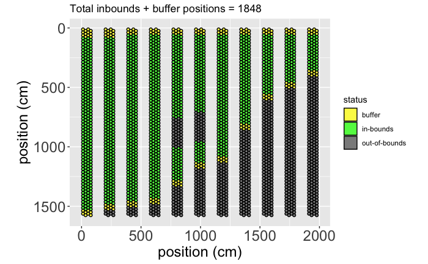

```r
plan3 <- plan3 %>%

  #top buffers:
  mutate(buffer=(row<=3 & bed %in% letters[1:2]) | (row <=2 & bed %in% letters[3:exp.beds]), # if you want different number of buffers in last row


  #bottom buffers
         buffer=ifelse(row > (bedrows[bedcol]-2) & row <= bedrows[bedcol], TRUE, buffer),
         status=ifelse(buffer, "buffer", inbounds)
  )

# plot it for reality check
plan3 %>%
  ggplot(aes(x0=x_pos, y0=y_pos, r=radius, fill=status)) +
  geom_circle(alpha=.75) +
  scale_fill_manual(values=c("out-of-bounds"="grey40", "in-bounds"="green",  "buffer" = "yellow")) +
  coord_equal() +
  #  geom_text(aes(x=x_pos, y=y_pos, label=bed), size= 14, data = bed.labels, inherit.aes = FALSE) +
  theme(axis.text = element_text(size=18), axis.title = element_text(size=18)) +
  xlab("position (cm)") + ylab("position (cm)") +
  scale_y_reverse() +
  ggtitle(str_c("Total inbounds + buffer positions = ", sum(plan3$inbounds=="in-bounds")))

ggsave("../output/2023-WL2-FieldPlan.jpeg", width = 10, height = 6)
```

### now combine them.

Should work to subset the plan3 to only have inbounds, then just do a column bind, and then add the rest (buffers and out-of-bounds) back in. Then do some swapping of row and column numbers in the even numbered beds.

arrange tibbles

```r
germinated <- germinated %>%
  ungroup() %>%
  arrange(block, row, column) %>%
  rename(blockrow=row, blockcolumn=column)

plan3 <- plan3 %>%
  ungroup() %>%
  arrange(bedcol, row, column) %>%
  rename(bedrow=row)
```

```r
plan3_plants <- plan3 %>%
  filter(status=="in-bounds") %>%
  bind_cols(germinated)

# reverse positions in even beds (to "snake" the blocks through the beds)
plan3_plants <- plan3_plants %>%
  group_by(bedcol) %>%
  mutate(across(.cols=block:`germinated?`, .fns= ~ ifelse(bedcol%%2==0, rev(.x), .x)))

# add back in the buffer and out of bounds rows
plan3_plants <- plan3 %>%
  filter(status!="in-bounds") %>%
  bind_rows(plan3_plants) %>%
  arrange(bed, bedrow, column)


# set up labels
plan3_plants <- plan3_plants %>%
  mutate(column=LETTERS[column]) %>%
  mutate(label=ifelse(buffer, "buff", str_c(parent.pop, "\n", mf, "-", rep) ),
         label=ifelse(status=="in-bounds" & parent.pop=="buffer", "buff", label),
         label=ifelse(is.na(label), "", label),
         colorblock=ifelse(is.na(block), status, block),
         colorblock=ifelse(status=="in-bounds" & parent.pop=="buffer", "buffer", colorblock))

plan3_plants
```

| bed | column | bedrow | radius | plantedcol | bedcol | y_pos | x_pos | inbounds | buffer | status | block | blockrow | blockcolumn | parent.pop | mf | rep | germinated? | label | colorblock |
| --- | --- | --- | --- | --- | --- | --- | --- | --- | --- | --- | --- | --- | --- | --- | --- | --- | --- | --- | --- |
| a | A | 1 | 12.5 | 1 | 1 | 12.5 | 12.50000 | in-bounds | TRUE | buffer | NA | NA | NA | NA | NA | NA | NA | buff | buffer |
| a | B | 1 | 12.5 | 2 | 1 | 25.0 | 34.15064 | in-bounds | TRUE | buffer | NA | NA | NA | NA | NA | NA | NA | buff | buffer |
| a | C | 1 | 12.5 | 3 | 1 | 12.5 | 55.80127 | in-bounds | TRUE | buffer | NA | NA | NA | NA | NA | NA | NA | buff | buffer |
| a | D | 1 | 12.5 | 4 | 1 | 25.0 | 77.45191 | in-bounds | TRUE | buffer | NA | NA | NA | NA | NA | NA | NA | buff | buffer |
| a | A | 2 | 12.5 | 1 | 1 | 37.5 | 12.50000 | in-bounds | TRUE | buffer | NA | NA | NA | NA | NA | NA | NA | buff | buffer |
| a | B | 2 | 12.5 | 2 | 1 | 50.0 | 34.15064 | in-bounds | TRUE | buffer | NA | NA | NA | NA | NA | NA | NA | buff | buffer |
| a | C | 2 | 12.5 | 3 | 1 | 37.5 | 55.80127 | in-bounds | TRUE | buffer | NA | NA | NA | NA | NA | NA | NA | buff | buffer |
| a | D | 2 | 12.5 | 4 | 1 | 50.0 | 77.45191 | in-bounds | TRUE | buffer | NA | NA | NA | NA | NA | NA | NA | buff | buffer |
| a | A | 3 | 12.5 | 1 | 1 | 62.5 | 12.50000 | in-bounds | TRUE | buffer | NA | NA | NA | NA | NA | NA | NA | buff | buffer |
| a | B | 3 | 12.5 | 2 | 1 | 75.0 | 34.15064 | in-bounds | TRUE | buffer | NA | NA | NA | NA | NA | NA | NA | buff | buffer |

[output cut: 990 more lines]

```r
pdf("../output/2023-WL2-planting_maps.pdf",width = 8.5, height = 11)

colors=c("grey40", "yellow", rep(c("magenta", "skyblue", "green"), length.out=length(germblocks))) %>%
  set_names("out-of-bounds", "buffer", germblocks)

for(b in unique(plan3_plants$bed)) {
  pl1 <- plan3_plants %>% filter(bed==b, bedrow<33) %>%
    ggplot(aes(x0=x_pos, y0=y_pos, r=radius, label=label, fill=colorblock)) +
    scale_fill_manual(values=colors) +
    geom_circle(alpha=.25, color="grey70") +
    geom_text(aes(x=x_pos, y=y_pos), size=3, lineheight=.8) +
    theme(axis.text.x = element_text(angle=90, size=12, vjust = 0.5)) +
    xlab("position (cm)") + ylab("position (cm)") +
    scale_y_reverse() +
    coord_equal(ratio=.4) +
    ggtitle(str_c("Bed ", b, ", sheet 1"))
  print(pl1)
  pl2 <- plan3_plants %>% filter(bed==b, bedrow>=33) %>%
    ggplot(aes(x0=x_pos, y0=y_pos, r=radius, label=label, fill=colorblock)) +
    scale_fill_manual(values=colors) +
    geom_circle(alpha=.25, color="grey70") +
    geom_text(aes(x=x_pos, y=y_pos), size=3, lineheight=.8) +
    theme(axis.text.x = element_text(angle=90, size=12, vjust = 0.5)) +
    xlab("position (cm)") + ylab("position (cm)") +
    scale_y_reverse() +
    coord_equal(ratio=.4) +
    ggtitle(str_c("Bed ", b, ", sheet 2"))
  print(pl2)
}

dev.off()
```

Randomization maps

```r
pdf("../output/2023-WL2-randomization_maps.pdf",width = 8.5, height = 11)

for(b in unique(germinated$block)) {
  pl <- germinated %>% filter(block==b) %>%
    mutate(label=ifelse(parent.pop=="buffer", "buff", str_c(parent.pop, "\n", mf, "-", rep) )) %>%
    mutate(label=ifelse(is.na(label), "buff", label)) %>%
    ggplot() +
    geom_label(aes(x=column, y=row, label=label), size=3, lineheight=.8) +
    theme(axis.text = element_text(size=12)) +
    scale_y_reverse(breaks = 1:31) +
    scale_x_discrete(position = "top") +
    ggtitle(str_c("Block ", b)) +
    coord_equal(ratio=.5)
  print(pl)
}

dev.off()
```